# Unsurprised

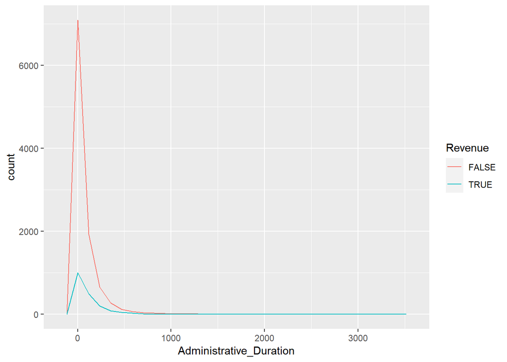

```r
ggplot(df, aes(Administrative_Duration, color=Revenue)) +
  geom_freqpoly()
```

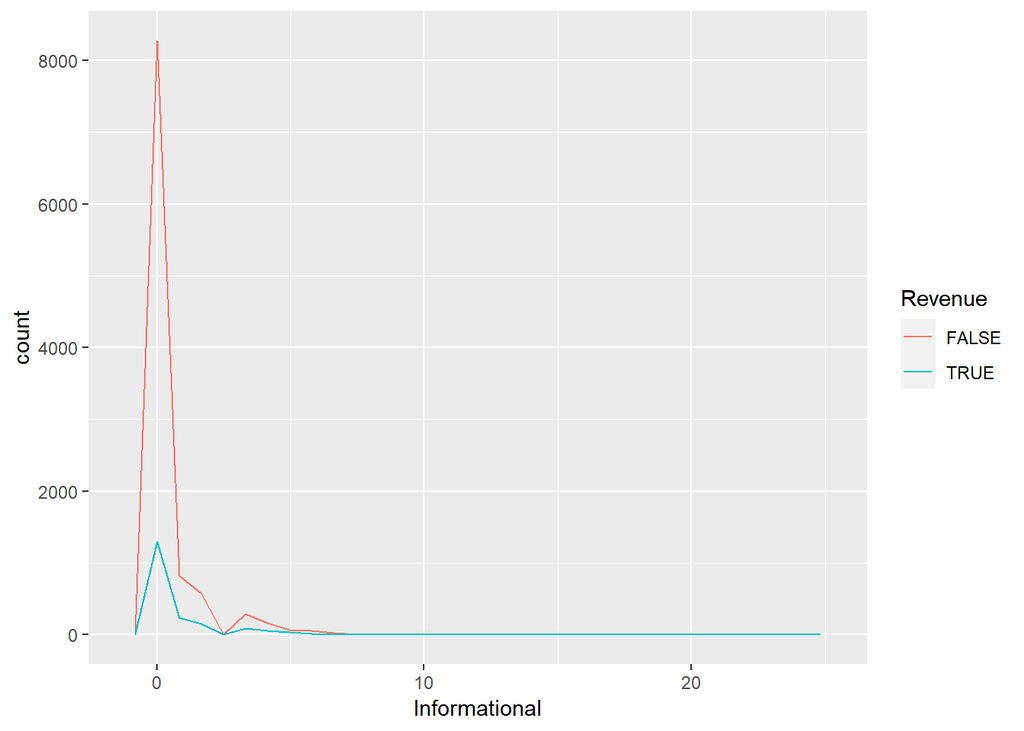

```r
ggplot(df, aes(Informational, color=Revenue)) +
  geom_freqpoly()
```

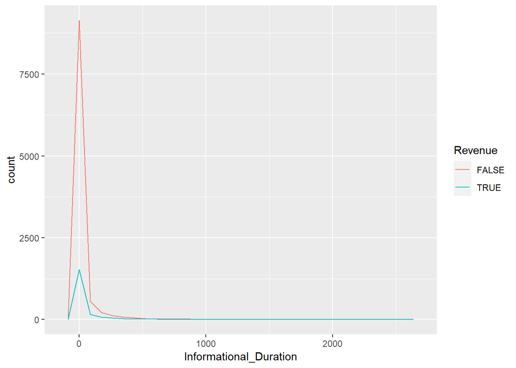

```r
ggplot(df, aes(Informational_Duration, color=Revenue)) +
  geom_freqpoly()
```

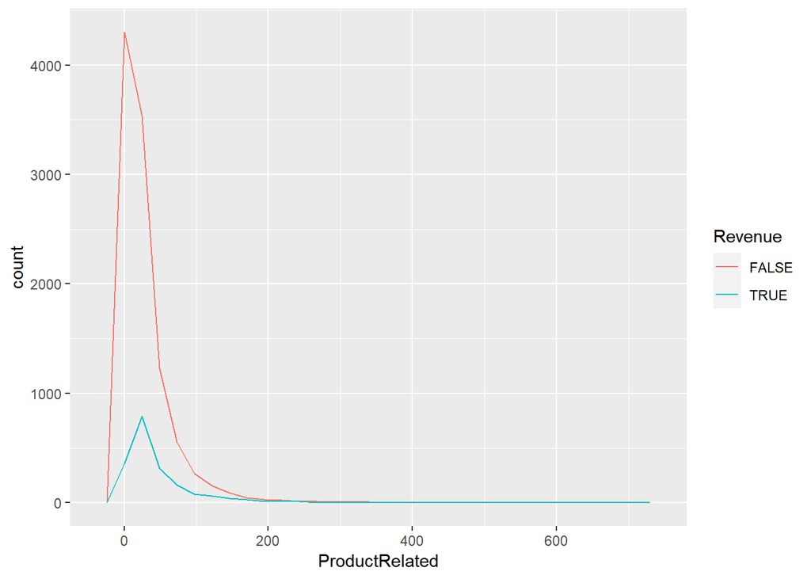

```r
ggplot(df, aes(ProductRelated, color=Revenue)) +
  geom_freqpoly()
```

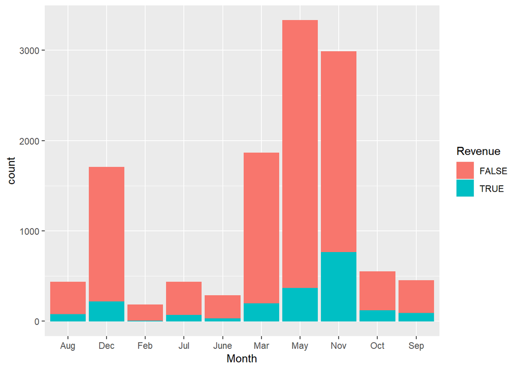

```r
# Months vs GeneratingRevenue
ggplot(df, aes(Month, color=Revenue, fill=Revenue)) +
  geom_bar(binwidth=1)
```

March, May, November and December are the months which generate significantly more revenue for the business.

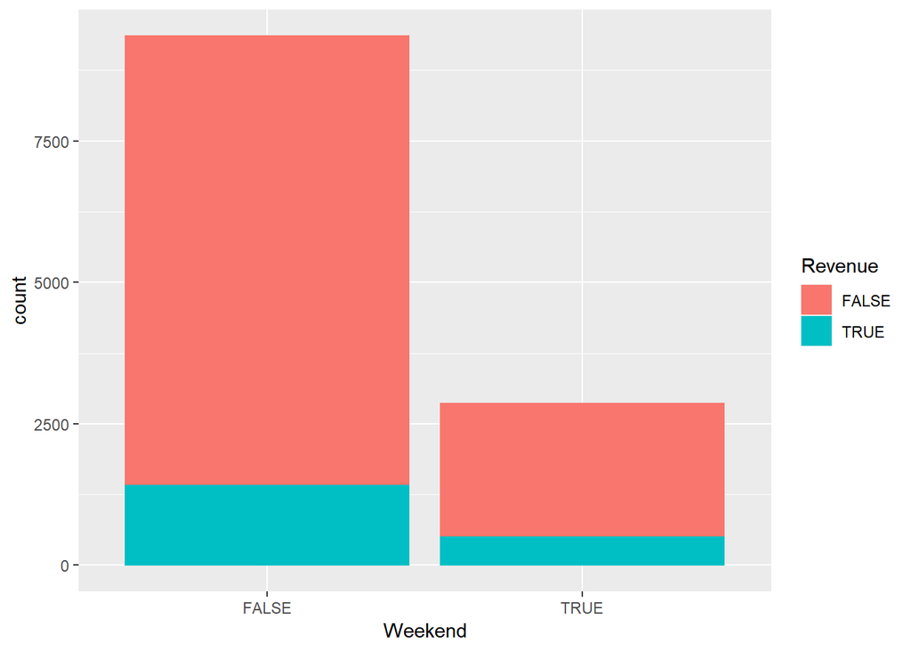

```r
# Day type vs Generating Revenue
ggplot(df, aes(Weekend, color=Revenue, fill=Revenue)) +
  geom_bar(binwidth=1)
```

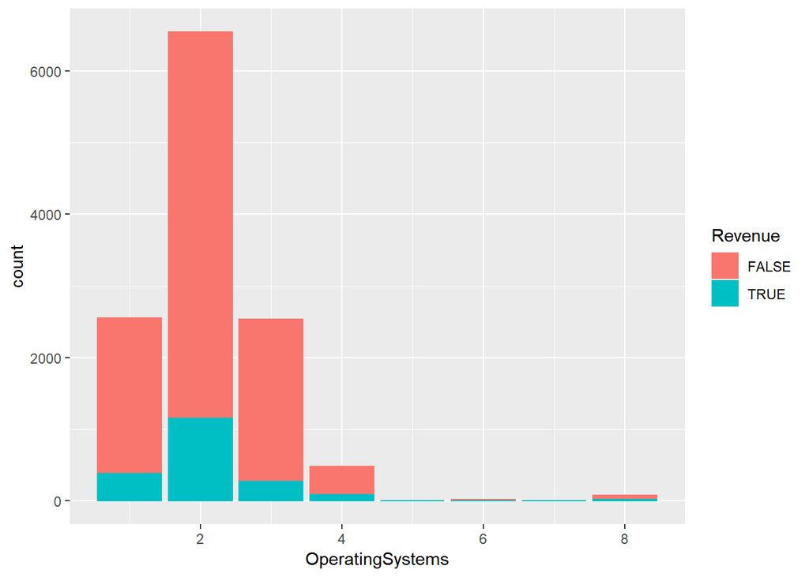

```r
# Operating systems vs Generating Revenue
ggplot(df, aes(OperatingSystems, color=Revenue, fill=Revenue)) +
  geom_bar()
```

Users of type 2 OS generated the most revenue for the site, while 1, and 3 followed.

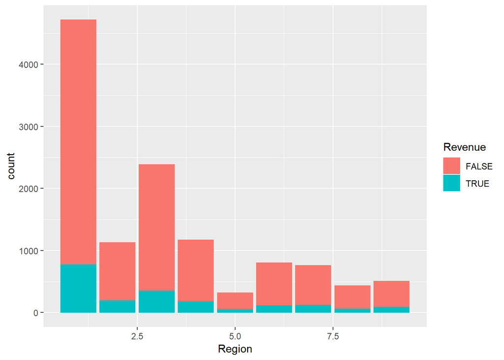

```r
ggplot(df, aes(Region, fill=Revenue, color=Revenue)) +
  geom_bar(binwidth=1)
```

Region 1 produced the most revenue out of all the others with region 5 producing the least.

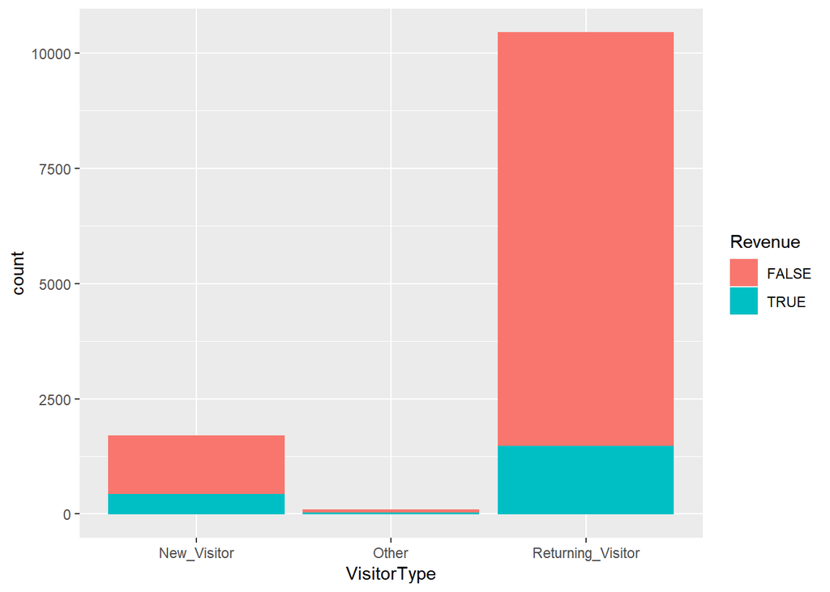

```r
# Visitor type and revenue
ggplot(df, aes(VisitorType, color=Revenue, fill=Revenue)) +
  geom_bar(binwidth=2)
```

Returning visitors generated a lot more revenue than new ones

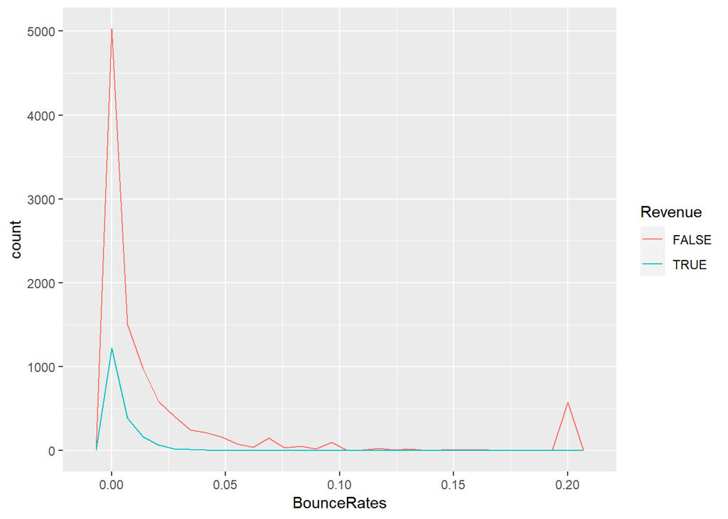

```r
ggplot(df, aes(BounceRates, color=Revenue)) +
  geom_freqpoly()
```

```r
cor(df[,unlist(lapply(df, is.numeric))])
```

```
##                         Administrative Administrative_Duration Informational
## Administrative             1.000000000             0.600409663   0.375287625
## Administrative_Duration    0.600409663             1.000000000   0.301436307
## Informational              0.375287625             0.301436307   1.000000000
## Informational_Duration     0.254786030             0.237189867   0.618677950
## ProductRelated             0.428191539             0.286783934   0.372604735
## ProductRelated_Duration    0.371027248             0.353513809   0.386083730
## BounceRates               -0.213666729            -0.137333462  -0.109505362
## ExitRates                 -0.311274177            -0.202024485  -0.159566852
## PageValues                 0.096918211             0.066166426   0.047388971
## SpecialDay                -0.097065467            -0.074732016  -0.049373282
## OperatingSystems          -0.006694960            -0.007607782  -0.009622395
## Browser                   -0.025758626            -0.015830515  -0.038760823
## Region                    -0.007259381            -0.006721474  -0.030469277
## TrafficType               -0.034758903            -0.015063876  -0.035161595
##                         Informational_Duration ProductRelated
## Administrative                     0.254786030     0.42819154
## Administrative_Duration            0.237189867     0.28678393
## Informational                      0.618677950     0.37260473
## Informational_Duration             1.000000000     0.27906196
## ProductRelated                     0.279061956     1.00000000
## ProductRelated_Duration            0.346580698     0.86030819
## BounceRates                       -0.070159509    -0.19351588
## ExitRates                         -0.102932699    -0.28616327
## PageValues                         0.030063390     0.05411486
## SpecialDay                        -0.031290846    -0.02592738
## OperatingSystems                  -0.009746665     0.00408998
## Browser                           -0.019606214    -0.01370276
## Region                            -0.027912876    -0.04009570
## TrafficType                       -0.025145674    -0.04431244
##                         ProductRelated_Duration  BounceRates    ExitRates
## Administrative                      0.371027248 -0.213666729 -0.311274177
## Administrative_Duration             0.353513809 -0.137333462 -0.202024485
## Informational                       0.386083730 -0.109505362 -0.159566852
## Informational_Duration              0.346580698 -0.070159509 -0.102932699
## ProductRelated                      0.860308191 -0.193515878 -0.286163267
## ProductRelated_Duration             1.000000000 -0.174375596 -0.245334071
## BounceRates                        -0.174375596  1.000000000  0.903358297
## ExitRates                          -0.245334071  0.903358297  1.000000000
## PageValues                          0.050839954 -0.115997874 -0.173572979
```

[output cut: 20 more lines]

```
##                               Region TrafficType
## Administrative          -0.007259381 -0.03475890
## Administrative_Duration -0.006721474 -0.01506388
## Informational           -0.030469277 -0.03516159
## Informational_Duration  -0.027912876 -0.02514567
## ProductRelated          -0.040095701 -0.04431244
## ProductRelated_Duration -0.034853079 -0.03747992
## BounceRates              0.001426743  0.08913142
## ExitRates               -0.001841360  0.08732060
## PageValues               0.010629461  0.01227262
## SpecialDay              -0.016407006  0.05283217
## OperatingSystems         0.071931190  0.18295673
## Browser                  0.091965004  0.10283138
## Region                   1.000000000  0.04271596
## TrafficType              0.042715962  1.00000000
```

The rates were significantly correlated while types of number of sites were strongly correlated with how much time was spent in them.

#### Data Preparation

```r
df$Weekend<- as.numeric(df$Weekend)
df$Revenue<- as.numeric(df$Revenue)
```

```r
# casting categorical columns as factors
df$Month <- factor(df$Month)
df$OperatingSystems <- factor(df$OperatingSystems)
df$Browser <- factor(df$Browser)
df$Region <- factor(df$Region)
df$TrafficType <- factor(df$TrafficType)
df$VisitorType <- factor(df$VisitorType)
df$Weekend <- factor(df$Weekend)
df$Revenue <- factor(df$Revenue)
```

```r
library(superml)
label <- LabelEncoder$new()
df$Month <- label$fit_transform(df$Month)
df$VisitorType <- label$fit_transform(df$VisitorType)
df$Weekend <- label$fit_transform(df$Weekend)
df$Revenue <- label$fit_transform(df$Revenue)
```